# Conversant Data Analysis

OVERVIEW:

Looking at the data.txt file, I tried to make sense of the column titles.

```
1. Type: obtained more clarification on rtb.requests (= real time bidding requests)
2. Time: figured out that values in the Time column areepoch times (= UNIX timestamp which represents number of seconds that have elapsed since 00:00:00 Thursday, 1 January 1970)
3. Value: Need more clarity on what this actually is, but my assumption would be the value to win the bid at the 'Time' and served by the 'Data center'
4. Data center: the data center serving the real time bidding request. At a glance there are 3 data centers, they could possibly span 3 different time zones.
```

ASSUMPTIONS:

```
1. Negative values in the "Value" column are anamolies
2. The epoch values of "Time" are arranged in ascending order per data center
3. The epoch values are constant time intervals, i.e., df['Value'].iloc[1] - df['Value'].iloc[0] = df['Value'].iloc[2] - df['Value'].iloc[1]
```

ANALYSIS:

The data spans over 3 days: starting at Jun 24, 14:06 to Jun 26 3:43 for 3 data centers in total.

My first attempt was to detect if there were any anamolies in the data. I found that there were only 22 negative values in the Value column out of a total of 1678 rows. Out of which Data center S (DC_S) seemed to have 19 of them.

Next, I found the first time stamp, last time stamp and number of requests for every data center. DC_I and DC_S start end at the same time but have different number of requests, this implies that the requests are not sampled at the same time interval for the data centers. In fact, given that we filtered out only 19 enteries of the total data center S enteries, number of requests for DC_S is not twice the number of requests for DC_I hints at unequal time interval. Extending this to DC_A proves my third assumption wrong. Further, the 19 negative values for requests being served by DC_S might be related to data being sampled more frequently than the other data centers.

INFORMATION NEEDED:

It would have been better if I understood what "Value" represented. Was it winning bid amount or value of resource used to serve the bid arriving at the given time in a particular data center.

```python
import pandas as pd
```

```python
#reading the data into a DataFrame
df = pd.read_csv('data.txt', sep="\t")
#get the initial count
df.count()
```

```
Type           1678
Time           1678
Value          1678
Data center    1678
dtype: int64
```

```python
#Filter the data to detect anamolies
df_anamolies = df[df['Value'] < 0]
print(df_anamolies)
print("\ntotal rtb.requests with a negative value:","\n",df_anamolies.count())
#As we see there are only 22 rtb.requests with a negative value from 1678 rtb.requests
#Out of 22, 19 are in Data center S
```

```
              Type        Time         Value Data center
142   rtb.requests  1561436280 -1.630443e+06        dc=I
444   rtb.requests  1561513680 -2.381560e+05        dc=I
450   rtb.requests  1561515840 -1.136099e+06        dc=I
679   rtb.requests  1561428000 -3.622098e+03        dc=S
680   rtb.requests  1561428060 -3.576098e+03        dc=S
683   rtb.requests  1561428720 -9.827333e+04        dc=S
684   rtb.requests  1561428780 -1.423256e+05        dc=S
685   rtb.requests  1561429080 -1.423637e+05        dc=S
717   rtb.requests  1561434840 -1.068289e+05        dc=S
718   rtb.requests  1561434900 -2.701923e+05        dc=S
719   rtb.requests  1561435200 -6.529927e+05        dc=S
720   rtb.requests  1561435260 -5.754178e+05        dc=S
780   rtb.requests  1561447620 -9.483367e+04        dc=S
781   rtb.requests  1561447920 -6.438304e+04        dc=S
805   rtb.requests  1561452240 -1.546532e+05        dc=S
806   rtb.requests  1561452300 -1.555278e+05        dc=S
814   rtb.requests  1561454040 -5.997929e+05        dc=S
815   rtb.requests  1561454400 -4.605180e+06        dc=S
816   rtb.requests  1561454460 -4.656151e+06        dc=S
817   rtb.requests  1561454760 -8.025340e+05        dc=S
1125  rtb.requests  1561515540 -2.494903e+05        dc=S
1126  rtb.requests  1561515840 -2.015454e+05        dc=S

total rtb.requests with a negative value:
 Type           22
Time           22
Value          22
Data center    22
dtype: int64
```

```python
#Filter the data to remove anamolies
df = df[df['Value'] > 0]
df.count()
```

```
Type           1656
Time           1656
Value          1656
Data center    1656
dtype: int64
```

```python
#Convert Epoch time to UTC format as Data centers could span multiple Time Zones
import time
def parse_timestamp(epoch_time):
        return{
            "date": time.strftime("%b %d", time.gmtime(epoch_time)),
            "hour": time.strftime("%H:%M", time.gmtime(epoch_time))
                                  }
df['Date'] = df.apply (lambda row: parse_timestamp(row['Time'])["date"], axis=1)
df['Hour'] = df.apply (lambda row: parse_timestamp(row['Time'])["hour"], axis=1)
```

```python
#Find how many data centers
data_centers = df['Data center'].unique()
print(data_centers)
```

```
['dc=I' 'dc=S' 'dc=A']
```

```python
#Sorting data per data center
df_I = df[df['Data center']=='dc=I']
df_S = df[df['Data center']=='dc=S']
df_A = df[df['Data center']=='dc=A']
#Find number of enteries
print('First epoch time:',parse_timestamp(df_I['Time'].iloc[0]), '\n# of requests dc=I:',df_I['Time'].count(),'\nLast epoch time',parse_timestamp(df_I['Time'].iloc[-1]))
print('\nFirst epoch time:',parse_timestamp(df_S['Time'].iloc[0]), '\n# of requests dc=S:',df_S['Time'].count(),'\nLast epoch time',parse_timestamp(df_S['Time'].iloc[-1]))
print('\nFirst epoch time:',parse_timestamp(df_A['Time'].iloc[0]), '\n# of requests dc=A:',df_A['Time'].count(),'\nLast epoch time',parse_timestamp(df_A['Time'].iloc[-1]))
```

```
First epoch time: {'date': 'Jun 24', 'hour': '14:06'}
# of requests dc=I: 461
Last epoch time {'date': 'Jun 26', 'hour': '03:42'}

First epoch time: {'date': 'Jun 24', 'hour': '14:06'}
# of requests dc=S: 670
Last epoch time {'date': 'Jun 26', 'hour': '03:42'}

First epoch time: {'date': 'Jun 24', 'hour': '14:07'}
# of requests dc=A: 525
Last epoch time {'date': 'Jun 26', 'hour': '03:43'}
```

```python
#Getting Maximun, Minimum and Mean of Values for every data center
print("DC_I-   Max: {} Min: {} Mean: {}".format(df_I['Value'].max(), df_I['Value'].min(), df_I['Value'].mean()))
print("DC_S-   Max: {} Min: {} Mean: {}".format(df_S['Value'].max(), df_S['Value'].min(), df_S['Value'].mean()))
print("DC_A-   Max: {} Min: {} Mean: {}".format(df_A['Value'].max(), df_A['Value'].min(), df_A['Value'].mean()))
```

```
DC_I-   Max: 61526.57777999999 Min: 5686.780556000001 Mean: 31343.795766006504
DC_S-   Max: 20725.35148 Min: 1032.790606 Mean: 8457.001338256716
DC_A-   Max: 5861.477778 Min: 1219.941667 Mean: 3592.9809935847616
```

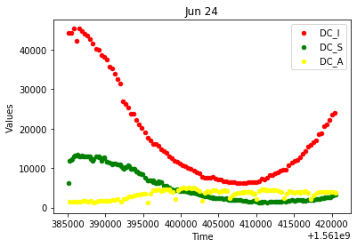

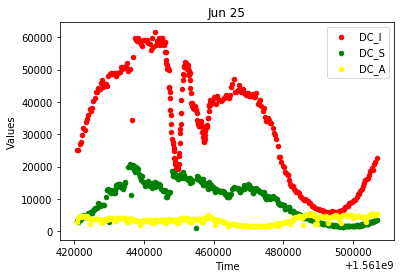

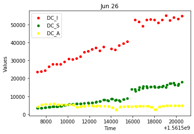

```python
#Plotting data per day for all Data center for comparison
days = ["Jun 24", "Jun 25", "Jun 26"]
for day in days:
    df_I_day = df_I[df_I['Date'] == day]
    df_S_day = df_S[df_S['Date'] == day]
    df_A_day = df_A[df_A['Date'] == day]

    ax_I=df_I_day.plot(kind='scatter', x='Time', y='Value', color='red',legend='great')
    ax_S=df_S_day.plot(ax=ax_I,kind='scatter', x='Time', y='Value',color='green',)
    ax_A=df_A_day.plot(ax=ax_S,kind='scatter', x='Time', y='Value',color='yellow',)
    ax_A.set(xlabel="Time", ylabel="Values", title=day)
    ax_A.legend(['DC_I', 'DC_S','DC_A'])
```

```
Enter the day as: Jun 24 / Jun 25 / Jun 26: Jun 24
```

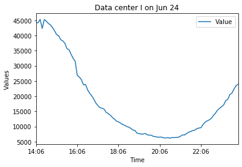

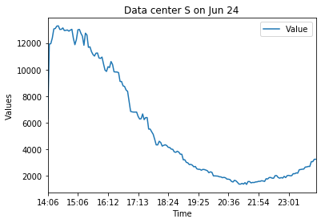

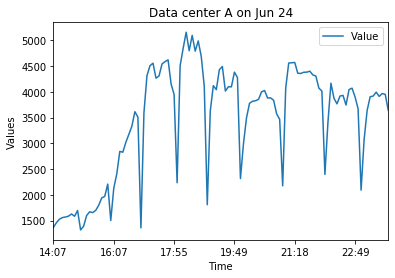

```python
#Detailed graphs for further analysis
#Plotting data for every data center on a given day
data_centers = [df_I, df_S, df_A]
day = input("Enter the day as: Jun 24 / Jun 25 / Jun 26: ")
def display_by_day(data_centers, day):
    data_center_names=['I','S','A']
    i = 0
    for data_center in data_centers:
        df_day = data_center[data_center['Date'] == day]
        ax = df_day.plot(kind='line', x='Hour', y='Value')
        ax.set(xlabel="Time", ylabel="Values", title="Data center {} on {}".format(data_center_names[i],day))
        i = i + 1
display_by_day(data_centers, day)
```

```
I, S or A: I
```

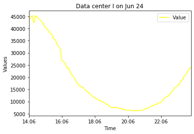

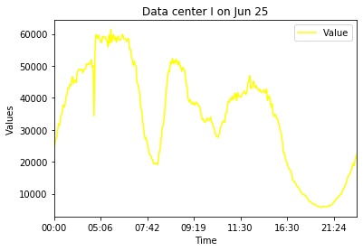

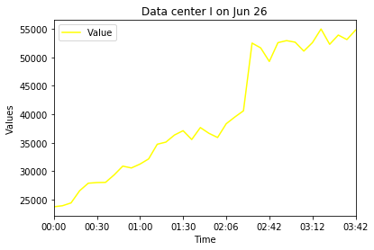

```python
#Plotting data for all three days for a given data center
def user_input(data_center_name):
    if data_center_name is "I":
        return df_I
    elif data_center_name is "S":
        return df_S
    elif data_center_name is "A":
        return df_A
    else:
        print("Please chose a valid data center name: I, S or A")

def display_by_data_center():
    data_center_name = input("I, S or A: ")
    days = ["Jun 24", "Jun 25", "Jun 26"]
    data_center = user_input(data_center_name)
    for day in days:
        df_day = data_center[data_center['Date'] == day]
        ax = df_day.plot(kind='line', x='Hour', y='Value', color='yellow')
        ax.set(xlabel="Time", ylabel="Values", title="Data center {} on {}".format(data_center_name,day))

display_by_data_center()
```